# PC2: Ejercicio de Text Mining

Adriana Mosqueira

2/7/2022

## **Usuario: @GabrielBoric, presidente electo de Chile**

# **Obtención de la base de datos**

## 1. Base de datos:

```r
boric = import("boric_gabriel.csv")
```

## 2. Información relevante:

#### Se obtuvo el periodo de tiempo al cual corresponden los tweets extraídos, los cuales van desde el 28 de noviembre del 2021 hasta el 11 de febrero del 2022

```r
max(boric$created_at); min(boric$created_at)
```

```
## [1] "2022-02-11 19:39:41 UTC"
```

```
## [1] "2021-11-28 20:49:04 UTC"
```

```r
head(boric$text)
```

```
## [1] "Se cae otro de los mitos de la campaña anti-constituyente: el derecho de propiedad. La Comisión de derechos funds. aprobó su reconocimiento y protección constitucional; no podía ser de otra manera. La constituyente avanza y de buena forma, a pesar de la estridencia que nos rodea. https://t.c…
## [2] "Duele la muerte de Bayron Castillo, nuestras condolencias a su familia. Nos preocupa la situación del norte y su gente y, por supuesto, reafirmamos nuestro compromiso de trabajar con todos los actores desde el primer día de nuestro gobierno en búsqueda de medidas efectivas."
## [3] "Tarea cumplida! \n\n¿Cómo están mis Brows? Yo aquí viviendo mi mejor vida con mi colchoncito en el que descanso por las tardes ¡Lo prometido es deuda! Investigué sobre cómo lidiar con quienes abusan de sus mascotas y es un mundo! https://t.co/H5rIKdChCR"
## [4] "Juan Carlos García (@jcgarciapdea): futuro Ministro de Obras Públicas\n\nArquitecto, magíster y máster en Gestión Urbana.\n\nFue parte del Centro Interdisciplinario de Neurociencia de la Universidad de Valparaíso y director Regional de Arquitectura de Valparaíso. https://t.co/d9TCM3RKJX"
## [5] "En la Comisión de Sistema Político, hemos rechazado esta propuesta para disolver los poderes del Estado, por unanimidad. La desconcentración del poder y la propia división de poderes son claves para nuestra democracia. https://t.co/INJGfDMd4c"
## [6] "Que irresponsabilidad más grande llamar a votar rechazo de un texto que aún no existe y que será fruto de la manera institucional en la fuimos capaces de salir de conflicto político social de proporciones !!!"
```

# **Procesamiento y análisis exploratorio**

## 1. Procesamiento de la base de datos

```r
textolimpio <- boric$text
textolimpio[1]
```

```
## [1] "Se cae otro de los mitos de la campaña anti-constituyente: el derecho de propiedad. La Comisión de derechos funds. aprobó su reconocimiento y protección constitucional; no podía ser de otra manera. La constituyente avanza y de buena forma, a pesar de la estridencia que nos rodea. https://t.c…
```

```r
library(tm)
micorpus <- Corpus(VectorSource(textolimpio))
length(micorpus)
```

```
## [1] 999
```

```r
content(micorpus[1])
```

```
## [1] "Se cae otro de los mitos de la campaña anti-constituyente: el derecho de propiedad. La Comisión de derechos funds. aprobó su reconocimiento y protección constitucional; no podía ser de otra manera. La constituyente avanza y de buena forma, a pesar de la estridencia que nos rodea. https://t.c…
```

```r
content(micorpus[1])
```

```
## [1] "Se cae otro de los mitos de la campaña anti-constituyente: el derecho de propiedad. La Comisión de derechos funds. aprobó su reconocimiento y protección constitucional; no podía ser de otra manera. La constituyente avanza y de buena forma, a pesar de la estridencia que nos rodea. https://t.c…
```

```r
micorpus <- tm_map(micorpus,content_transformer(tolower))
content(micorpus[1])
```

```
## [1] "se cae otro de los mitos de la campaña anti-constituyente: el derecho de propiedad. la comisión de derechos funds. aprobó su reconocimiento y protección constitucional; no podía ser de otra manera. la constituyente avanza y de buena forma, a pesar de la estridencia que nos rodea. https://t.c…
```

```r
content(micorpus[1])
```

```
## [1] "se cae otro de los mitos de la campaña anti-constituyente: el derecho de propiedad. la comisión de derechos funds. aprobó su reconocimiento y protección constitucional; no podía ser de otra manera. la constituyente avanza y de buena forma, a pesar de la estridencia que nos rodea. https://t.c…
```

```r
removerURL <- function(x) gsub("http[^[:space:]]*", "", x)
micorpus <- tm_map(micorpus, content_transformer(removerURL))
content(micorpus[1])
```

```
## [1] "se cae otro de los mitos de la campaña anti-constituyente: el derecho de propiedad. la comisión de derechos funds. aprobó su reconocimiento y protección constitucional; no podía ser de otra manera. la constituyente avanza y de buena forma, a pesar de la estridencia que nos rodea. "
```

```r
content(micorpus[1])
```

```
## [1] "se cae otro de los mitos de la campaña anti-constituyente: el derecho de propiedad. la comisión de derechos funds. aprobó su reconocimiento y protección constitucional; no podía ser de otra manera. la constituyente avanza y de buena forma, a pesar de la estridencia que nos rodea. "
```

```r
removerTILDE <- function(x) chartr('áéíóú','aeiou',x)
micorpus <- tm_map(micorpus, removerTILDE)
content(micorpus[1])
```

```
## [1] "se cae otro de los mitos de la campaña anti-constituyente: el derecho de propiedad. la comision de derechos funds. aprobo su reconocimiento y proteccion constitucional; no podia ser de otra manera. la constituyente avanza y de buena forma, a pesar de la estridencia que nos rodea. "
```

```r
content(micorpus[1])
```

```
## [1] "se cae otro de los mitos de la campaña anti-constituyente: el derecho de propiedad. la comision de derechos funds. aprobo su reconocimiento y proteccion constitucional; no podia ser de otra manera. la constituyente avanza y de buena forma, a pesar de la estridencia que nos rodea. "
```

```r
remover <- function(x) chartr('?','n',x)
micorpus <- tm_map(micorpus, remover)
content(micorpus[1])
```

```
## [1] "se cae otro de los mitos de la campaña anti-constituyente: el derecho de propiedad. la comision de derechos funds. aprobo su reconocimiento y proteccion constitucional; no podia ser de otra manera. la constituyente avanza y de buena forma, a pesar de la estridencia que nos rodea. "
```

```r
content(micorpus[1])
```

```
## [1] "se cae otro de los mitos de la campaña anti-constituyente: el derecho de propiedad. la comision de derechos funds. aprobo su reconocimiento y proteccion constitucional; no podia ser de otra manera. la constituyente avanza y de buena forma, a pesar de la estridencia que nos rodea. "
```

```r
removerUSUARIOS <- function(x) gsub("@\\w+", "", x)
micorpus <- tm_map(micorpus, removerUSUARIOS)
content(micorpus[1])
```

```
## [1] "se cae otro de los mitos de la campaña anti-constituyente: el derecho de propiedad. la comision de derechos funds. aprobo su reconocimiento y proteccion constitucional; no podia ser de otra manera. la constituyente avanza y de buena forma, a pesar de la estridencia que nos rodea. "
```

```r
content(micorpus[1])
```

```
## [1] "se cae otro de los mitos de la campaña anti-constituyente: el derecho de propiedad. la comision de derechos funds. aprobo su reconocimiento y proteccion constitucional; no podia ser de otra manera. la constituyente avanza y de buena forma, a pesar de la estridencia que nos rodea. "
```

```r
micorpus <- tm_map(micorpus, removePunctuation)
content(micorpus[1])
```

```
## [1] "se cae otro de los mitos de la campaña anticonstituyente el derecho de propiedad la comision de derechos funds aprobo su reconocimiento y proteccion constitucional no podia ser de otra manera la constituyente avanza y de buena forma a pesar de la estridencia que nos rodea "
```

```r
content(micorpus[23])
```

```
## [1] "  "
```

```r
micorpus <- tm_map(micorpus, removeNumbers)
content(micorpus[23])
```

```
## [1] "  "
```

```r
content(micorpus[1])
```

```
## [1] "se cae otro de los mitos de la campaña anticonstituyente el derecho de propiedad la comision de derechos funds aprobo su reconocimiento y proteccion constitucional no podia ser de otra manera la constituyente avanza y de buena forma a pesar de la estridencia que nos rodea "
```

```r
micorpus <- tm_map(micorpus, removeWords,c(stopwords("spanish")))
content(micorpus[1])
```

```
## [1] " cae    mitos   campaña anticonstituyente  derecho  propiedad  comision  derechos funds aprobo  reconocimiento  proteccion constitucional  podia ser   manera  constituyente avanza   buena forma  pesar   estridencia   rodea "
```

```r
content(micorpus[1])
```

```
## [1] " cae    mitos   campaña anticonstituyente  derecho  propiedad  comision  derechos funds aprobo  reconocimiento  proteccion constitucional  podia ser   manera  constituyente avanza   buena forma  pesar   estridencia   rodea "
```

```r
micorpus <- tm_map(micorpus, stripWhitespace)
content(micorpus[1])
```

```
## [1] " cae mitos campaña anticonstituyente derecho propiedad comision derechos funds aprobo reconocimiento proteccion constitucional podia ser manera constituyente avanza buena forma pesar estridencia rodea "
```

```r
removerRETWEETS <- function(x) gsub("(RT|via)((?:\\b\\W*@\\w+)+)", "", x)
micorpus <- tm_map(micorpus, removerRETWEETS)
content(micorpus[1])
```

```
## [1] " cae mitos campaña anticonstituyente derecho propiedad comision derechos funds aprobo reconocimiento proteccion constitucional podia ser manera constituyente avanza buena forma pesar estridencia rodea "
```

## 2. Term document matrix

```r
term <- TermDocumentMatrix(micorpus)
```

```r
findFreqTerms(term,lowfreq = 20)
```

```
##  [1] "campaña"         "derecho"         "derechos"        "ser"
##  [5] "compromiso"      "dia"             "gente"           "gobierno"
##  [9] "estan"           "mejor"           "vida"            "futuro"
## [13] "parte"           "democracia"      "poder"           "sistema"
## [17] "mas"             "sera"            "votar"           "seguimos"
## [21] "chile"           "hacia"           "ministra"        "trabajo"
## [25] "pais"            "electo"          "hoy"             "presidente"
## [29] "subsecretaria"   "nacional"        "equipo"          "respeto"
## [33] "gran"            "mujer"           "solo"            "vivir"
## [37] "todas"           "cultura"         "nuevo"           "tambien"
## [41] "ver"             "trabajaremos"    "personas"        "domingo"
## [45] "entrevista"      "años"            "mujeres"         "gracias"
## [49] "muchas"          "abrazo"          "boric"           "gabriel"
## [53] "hacer"           "honor"           "siempre"         "confianza"
## [57] "desafios"        "construir"       "cada"            "encuentro"
## [61] "dias"            "queremos"        "tener"           "desafio"
## [65] "programa"        "esperanza"       "agradezco"       "proyecto"
## [69] "apoyo"           "junto"           "alegria"         "avanzar"
## [73] "chilenos"        "juntos"          "vamos"           "miedo"
## [77] "justo"           "mañana"          "salud"           "kast"
## [81] "candidato"       "diciembre"       "vota"            "propuestas"
## [85] "boricpresidente" "franjaelectoral" "votauno"
```

```r
m <- as.matrix(term)
head(m)
```

[output not shown]

[output cut: 465 more lines]

[output not shown]

#### Procederemos a identificar la cantidad de veces que cada una de las palabras ha sido utilizada

```r
wf <- sort(rowSums(m),decreasing=TRUE)
wf
```

[output not shown]

[output cut: 9905 more lines]

[output not shown]

```r
head(wf)
```

```
##      chile        mas        hoy presidente      mejor    gracias
##        204        123        118        114        113        112
```

```r
dm <- data.frame(word = names(wf), freq=wf)
head(dm)
```

```
##                  word freq
## chile           chile  204
## mas               mas  123
## hoy               hoy  118
## presidente presidente  114
## mejor           mejor  113
## gracias       gracias  112
```

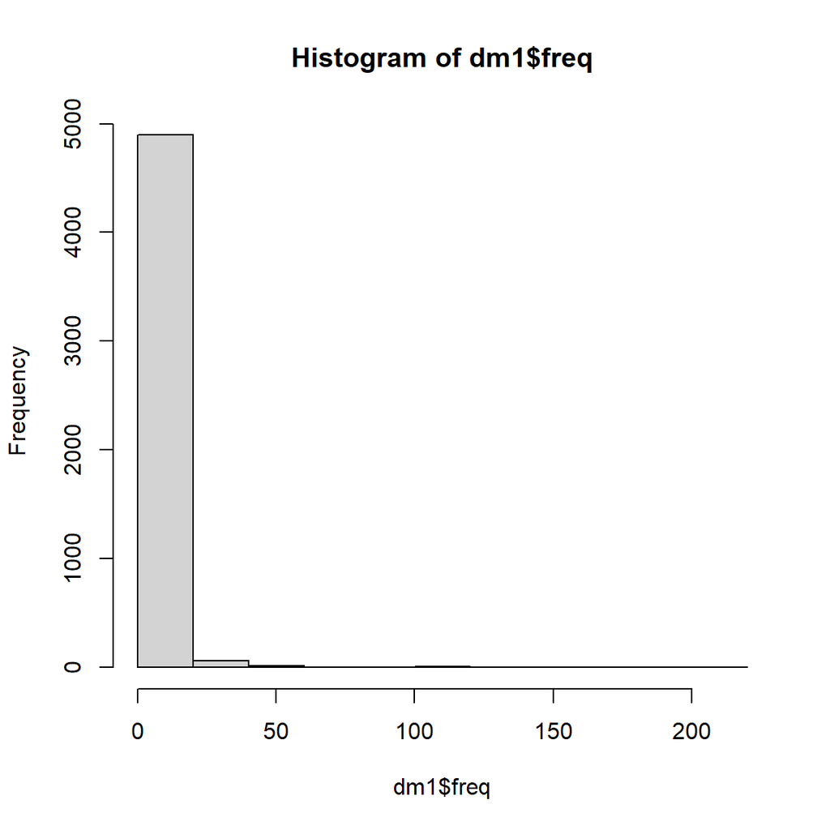

```r
dm1 <- dm
hist(dm1$freq)
```

```r
dm1 <- subset(dm1, dm1$freq >= 10)
dm1
```

```
##                                      word freq
## chile                               chile  204
## mas                                   mas  123
## hoy                                   hoy  118
## presidente                     presidente  114
## mejor                               mejor  113
## gracias                           gracias  112
## gobierno                         gobierno   97
## pais                                 pais   86
## boric                               boric   78
## todas                               todas   61
## seguimos                         seguimos   59
## campaña                           campaña   56
## electo                             electo   48
## dia                                   dia   47
## tambien                           tambien   47
## personas                         personas   46
## ser                                   ser   45
## gabriel                           gabriel   45
## esperanza                       esperanza   45
## vivir                               vivir   44
## boricpresidente           boricpresidente   42
## trabajo                           trabajo   40
## confianza                       confianza   40
## diciembre                       diciembre   40
## muchas                             muchas   38
## apoyo                               apoyo   38
## vota                                 vota   38
## futuro                             futuro   37
## compromiso                     compromiso   36
## años                                 años   36
## vamos                               vamos   35
## equipo                             equipo   34
## franjaelectoral           franjaelectoral   34
## parte                               parte   32
## sera                                 sera   32
## votauno                           votauno   32
## derechos                         derechos   30
## solo                                 solo   29
## mujeres                           mujeres   29
```

[output cut: 186 more lines]

```
## comunidad                       comunidad   10
## esperamos                       esperamos   10
## genero                             genero   10
## aporte                             aporte   10
## debate                             debate   10
## escuchar                         escuchar   10
## tema                                 tema   10
## invitamos                       invitamos   10
## dejo                                 dejo   10
## familias                         familias   10
## necesita                         necesita   10
## necesitan                       necesitan   10
## vuelta                             vuelta   10
## podamos                           podamos   10
## apoyar                             apoyar   10
```

## 3. Diagrama de barras: Top 20 de las palabras más usadas

#### A continuación se muestra gráficamente las 20 palabras más utilizadas dentro de los tweets realizados.

[figure not shown]

```r
ggplot(dm1, aes( x= word, y=freq )) + geom_bar(stat="identity") +
  xlab("Terminos") + ylab("Frecuencia") + coord_flip() +
  theme(axis.text=element_text(size=7)) + geom_text(aes(hjust = 1.3, label = freq))
```

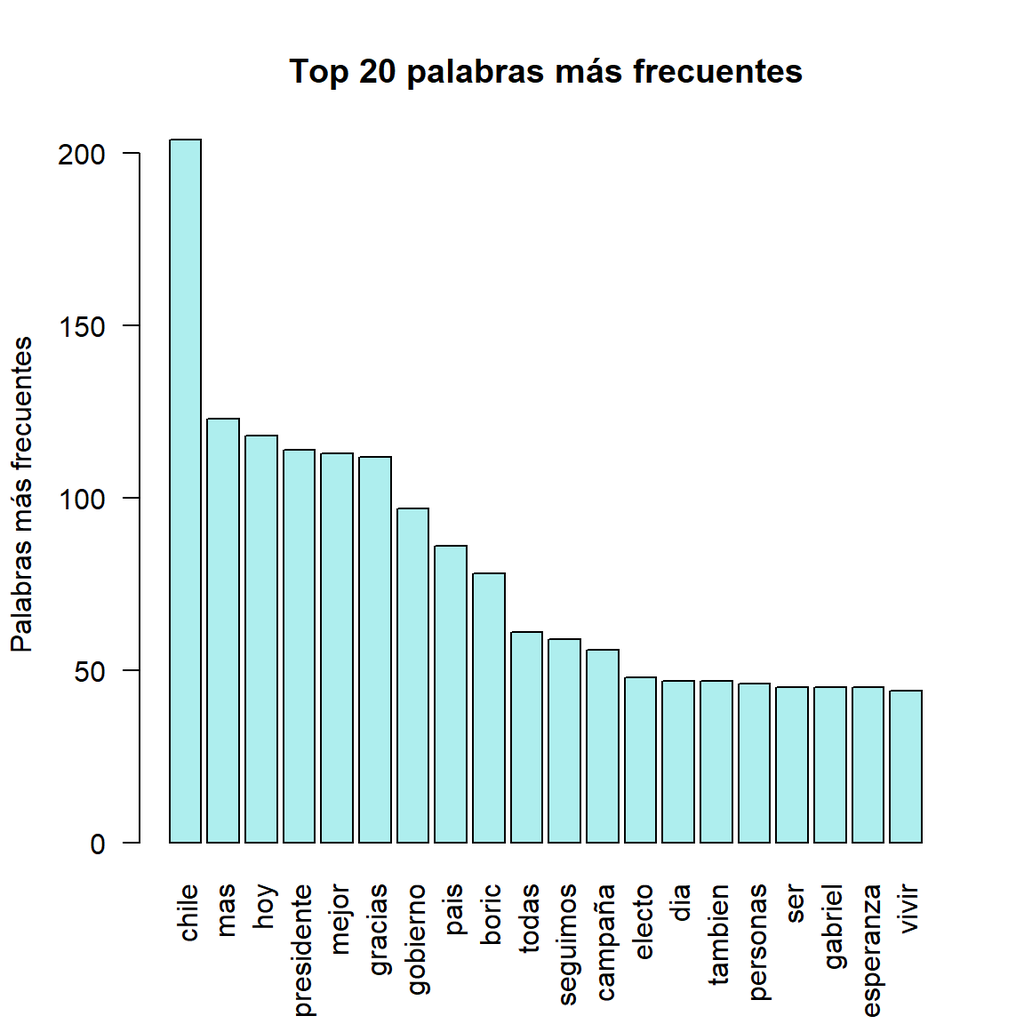

```r
barplot(dm1[1:20,]$freq, las = 2, names.arg = dm1[1:20,]$word,
        col ="paleturquoise2", main ="Top 20 palabras más frecuentes",
        ylab = "Palabras más frecuentes")
```

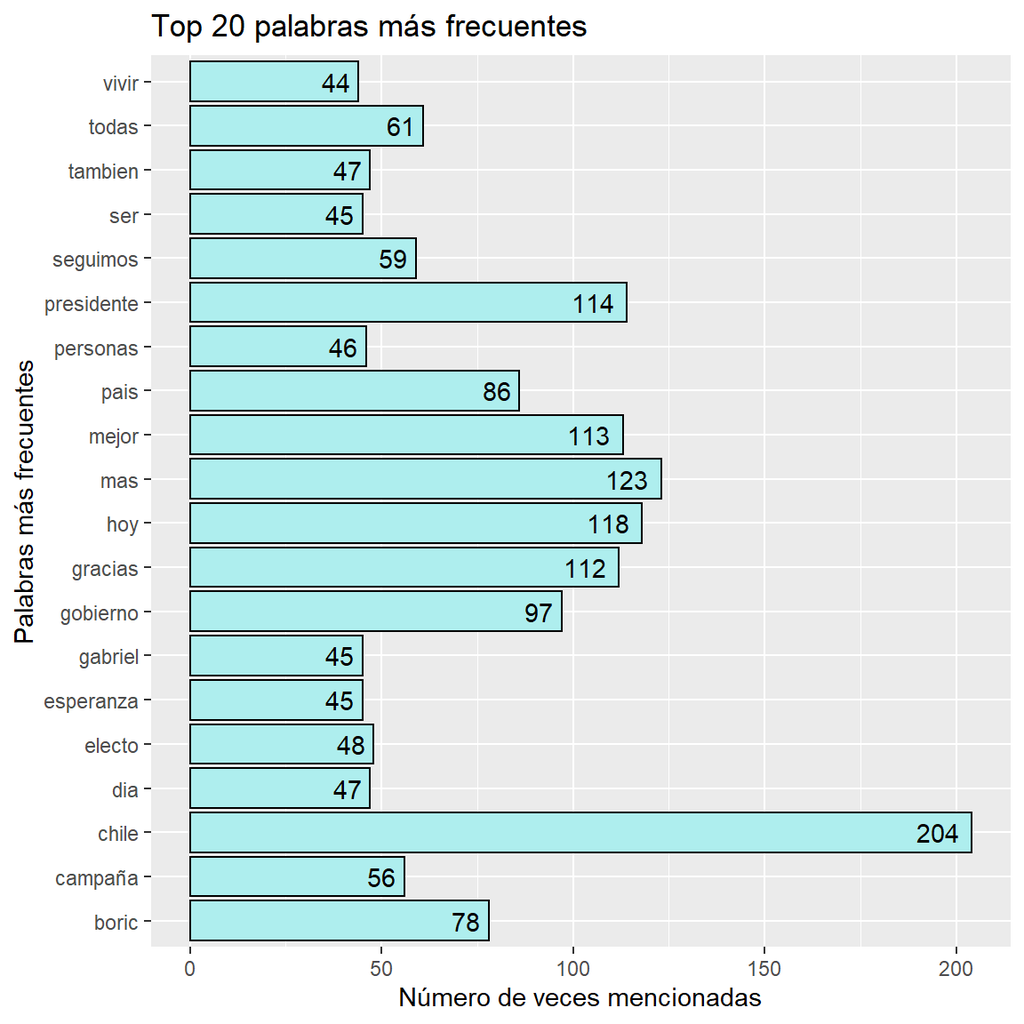

```r
dm1[1:20, ] %>%
  ggplot(aes(word, freq)) +
  geom_bar(stat = "identity", color = "black", fill = "paleturquoise2") +
  geom_text(aes(hjust = 1.3, label = freq)) +
  coord_flip() +
  labs(title = "Top 20 palabras más frecuentes",  x = "Palabras más frecuentes", y = "Número de veces mencionadas")
```

## 4. Word Cloud

#### También se realiza un word cloud con el Top 100 de palabras más utilizadas durante este period de tiempo, por este usuario

```r
library(wordcloud)
head(dm)
```

```
##                  word freq
## chile           chile  204
## mas               mas  123
## hoy               hoy  118
## presidente presidente  114
## mejor           mejor  113
## gracias       gracias  112
```

```r
termcount <- data.frame(freq = apply(term,1,sum))
head(termcount)
```

```
##                   freq
## anticonstituyente    1
## aprobo               1
## avanza               4
## buena               10
## cae                  4
## campaña             56
```

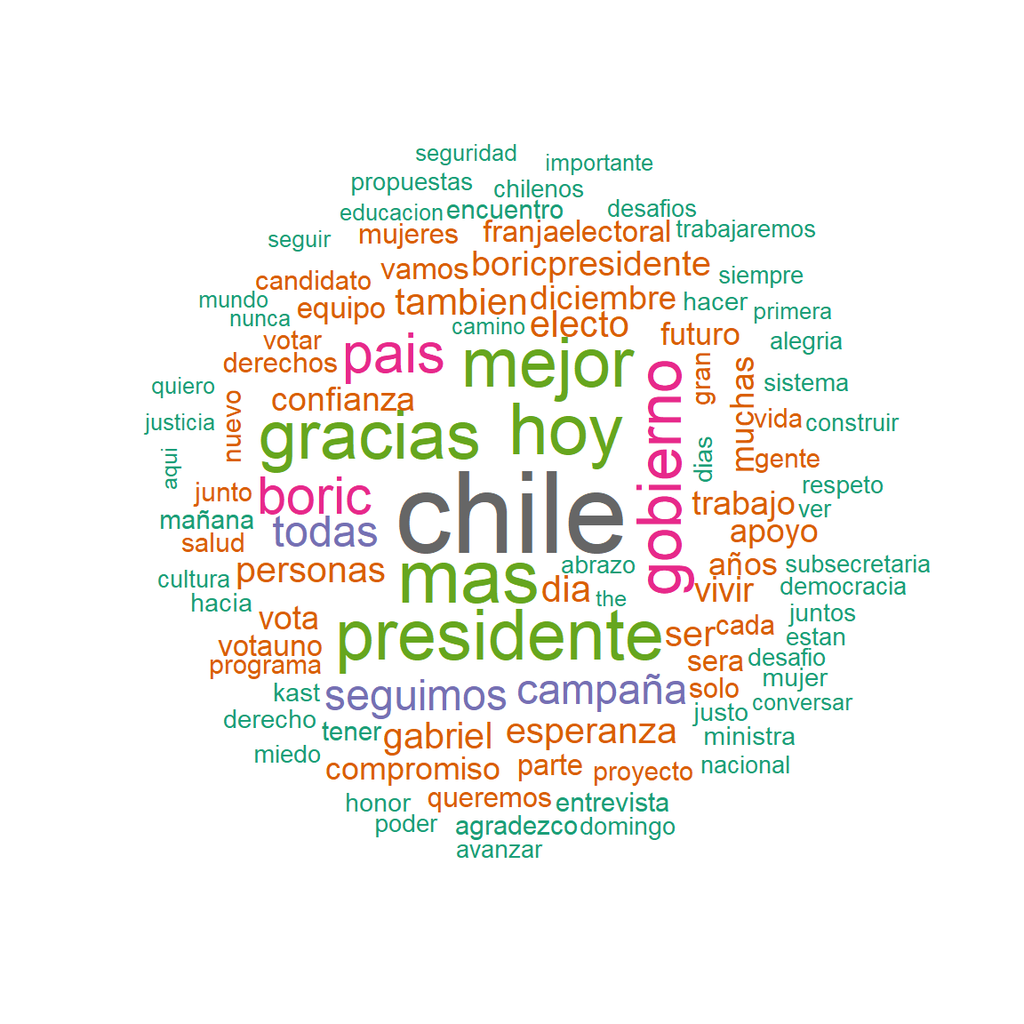

```r
wordcloud(dm$word, dm$freq, max.words = 100, random.order=FALSE, min.freq=2, colors=brewer.pal(8, "Dark2"))
```

# **Modelamiento**

## 1. Palabras asociadas

#### A partir de la nube de palabras y el gráfico de barras, se identificaron algunas palabras que podrían estar asociadas con otras en un 0.3 a más.

```r
findAssocs(term, c("salud", "educacion", "agua"), c(0.50))
```

```
## $salud
## mental
##   0.53
##
## $educacion
##     castellano vulnerabilidad         ã\201vila          marco
##           0.58           0.58           0.58           0.54
##
## $agua
## garantizada     petorca
##        0.72        0.59
```

```r
findAssocs(term, c("esperanza", "mujer", "confianza", "vulnerables"), c(0.30))
```

```
## $esperanza
## miedo  gane
##  0.38  0.36
##
## $mujer
##       casadas   discriminar      madreâ\200\235       obligar      solteras
##          0.54          0.54          0.54          0.54          0.54
##       violada       equidad        cerrar      expresar     subsidios
##          0.54          0.43          0.38          0.38          0.38
##        abuela        luchar       paterna        genero      distinta
##          0.36          0.36          0.36          0.33          0.31
##    ministerio
##          0.30
##
## $confianza
##  agradezco      asumo presidente
##       0.51       0.33       0.32
##
## $vulnerables
##      achicar      estarlo      jueguen        ¡tras       cancha   tranquilos
##         1.00         1.00         1.00         1.00         0.71         0.71
##     bernardo     cansados   eficiencia        rejas        narco    mejorando
##         0.71         0.71         0.71         0.71         0.58         0.50
## delincuencia  reafirmamos      barrios     policias        deben     familias
##         0.45         0.41         0.41         0.35         0.33         0.31
```

```r
findAssocs(term, c("estudiantes", "derechos", "personas", "trabajadores"), c(0.30))
```

```
## $estudiantes
##        abogada administradora     federacion           jara      jeannette
##           1.00           1.00           1.00           1.00           1.00
##      prevision         social        publica    universidad       santiago
##           0.89           0.53           0.38           0.35           0.30
##
## $derechos
## humanos
##    0.51
##
## $personas
## mayores
##    0.34
##
## $trabajadores
##              basado          bienvenida               damos   derechoalacultura
##                0.35                0.35                0.35                0.35
##                 lxs              solido               araya             castulo
##                0.35                0.35                0.35                0.35
##           conductor            despidio           dirigente     espontaneamente
##                0.35                0.35                0.35                0.35
##         felicitaron            periodos            sindical                ðÿ¥º
##                0.35                0.35                0.35                0.35
##       corporaciones           dedicadas     emprendimientos           necesitar
##                0.35                0.35                0.35                0.35
##         recuperarse            ausentes             codelco             comites
##                0.35                0.35                0.35                0.35
##             mejoras       privatizacion          sindicatos             modelos
##                0.35                0.35                0.35                0.35
##            salvarse           urgencias diadelmedicoymedica            homenaje
##                0.35                0.35                0.35                0.35
##             medicos           pacientes              salvar               vidas
##                0.35                0.35                0.35                0.35
##             enormes                sere            ahorrado            extender
##                0.35                0.35                0.35                0.35
##             respete           pasajeros
##                0.35                0.31
```

## 2. Clúster de palabras

#### Para ello, será necesario eliminar aquellas palabras menos frecuentes, o más dispersas

```r
term_new <- removeSparseTerms(term, sparse = 0.96)
m2 <- as.matrix(term_new)
term_new$nrow
```

```
## [1] 23
```

```r
term$nrow
```

```
## [1] 4980
```

#### Con las 23 palabras menos dispersas, filtradas en el paso anterior, se solicita contruir 3 clúster y que estas seas mostradas en un dendograma

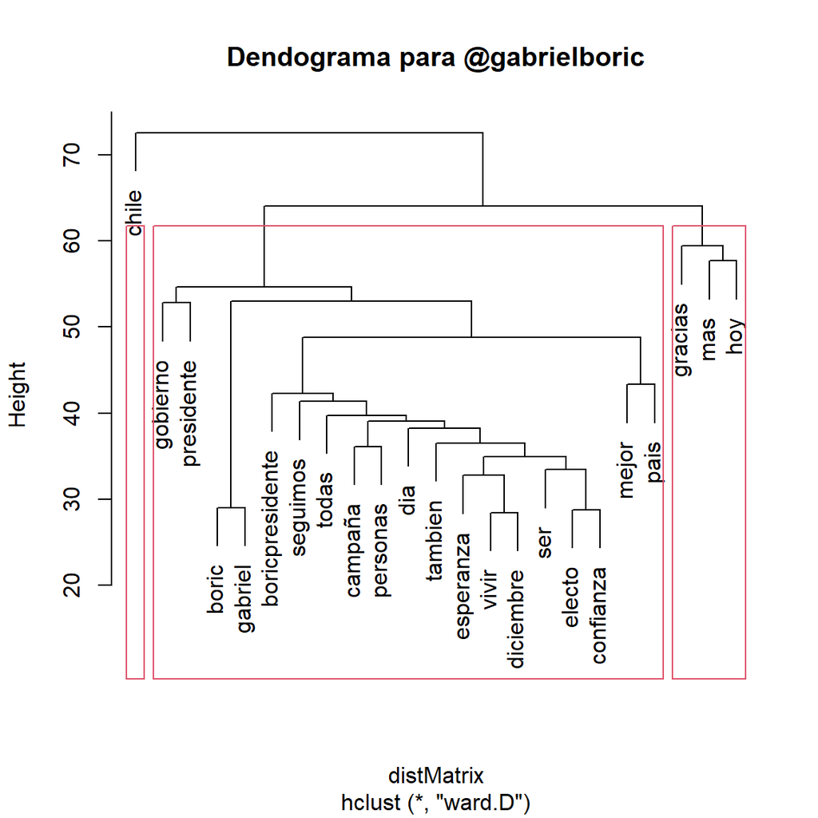

```r
distMatrix <- dist(scale(m2))
fit <- hclust(distMatrix, method = "ward.D")
plot(fit, main = "Dendograma para @gabrielboric")
rect.hclust(fit, k = 3)
```

## 3. Análisis de sentimientos

#### Finalmente se realiza un análisis de sentimientos, a partir del cual se identican 3 grupos: sentimientos neutrales, sentimientos positivos y sentimientos negativos

```r
#install.packages("SentimentAnalysis")
library(SentimentAnalysis)
```

#### Se identifica que la mayoría de palabras muestran sentimientos neutrales, mientras que 137 aluden a sentimientos positivos y las 46 restantes implican sentimientos negativos

```r
sentimientos <- analyzeSentiment(textolimpio,language = "spanish")

sentimientos_final <- data.frame(textolimpio,
                                 sentiment = convertToDirection(sentimientos$SentimentGI))
head(sentimientos_final)
```

```
##                                                                                                                                                                                                                                                                                                        te…
## 1 Se cae otro de los mitos de la campaña anti-constituyente: el derecho de propiedad. La Comisión de derechos funds. aprobó su reconocimiento y protección constitucional; no podía ser de otra manera. La constituyente avanza y de buena forma, a pesar de la estridencia que nos rodea. https://t.co/S…
## 2                               Duele la muerte de Bayron Castillo, nuestras condolencias a su familia. Nos preocupa la situación del norte y su gente y, por supuesto, reafirmamos nuestro compromiso de trabajar con todos los actores desde el primer día de nuestro gobierno en búsqueda de medidas e…
## 3                                                    Tarea cumplida! \n\n¿Cómo están mis Brows? Yo aquí viviendo mi mejor vida con mi colchoncito en el que descanso por las tardes ¡Lo prometido es deuda! Investigué sobre cómo lidiar con quienes abusan de sus mascotas y es un mundo! https://t.co/H…
## 4                  Juan Carlos García (@jcgarciapdea): futuro Ministro de Obras Públicas\n\nArquitecto, magíster y máster en Gestión Urbana.\n\nFue parte del Centro Interdisciplinario de Neurociencia de la Universidad de Valparaíso y director Regional de Arquitectura de Valparaíso. https://t.co/d…
## 5                                                               En la Comisión de Sistema Político, hemos rechazado esta propuesta para disolver los poderes del Estado, por unanimidad. La desconcentración del poder y la propia división de poderes son claves para nuestra democracia. https://t.co/I…
## 6                                                                                                 Que irresponsabilidad más grande llamar a votar rechazo de un texto que aún no existe y que será fruto de la manera institucional en la fuimos capaces de salir de conflicto político social de proporc…
##   sentiment
## 1   neutral
## 2   neutral
## 3   neutral
## 4   neutral
## 5   neutral
## 6  positive
```

```r
str(sentimientos_final)
```

```
## 'data.frame':    999 obs. of  2 variables:
##  $ textolimpio: chr  "Se cae otro de los mitos de la campaña anti-constituyente: el derecho de propiedad. La Comisión de derechos fun"| __truncated__ "Duele la muerte de Bayron Castillo, nuestras condolencias a su familia. Nos preocupa la situación del norte y s"| __truncated__ "Tarea cumplida! \…
##  $ sentiment  : Factor w/ 3 levels "negative","neutral",..: 2 2 2 2 2 3 3 2 2 2 ...
```

```r
table(sentimientos_final$sentiment)
```

```
##
## negative  neutral positive
##       46      816      137
```

```r
sentimientos_final$score <- 0
sentimientos_final$score[sentimientos_final$sentiment == "positive"] <- 1
sentimientos_final$score[sentimientos_final$sentiment == "negative"] <- -1

head(sentimientos_final)
```

```
##                                                                                                                                                                                                                                                                                                        te…
## 1 Se cae otro de los mitos de la campaña anti-constituyente: el derecho de propiedad. La Comisión de derechos funds. aprobó su reconocimiento y protección constitucional; no podía ser de otra manera. La constituyente avanza y de buena forma, a pesar de la estridencia que nos rodea. https://t.co/S…
## 2                               Duele la muerte de Bayron Castillo, nuestras condolencias a su familia. Nos preocupa la situación del norte y su gente y, por supuesto, reafirmamos nuestro compromiso de trabajar con todos los actores desde el primer día de nuestro gobierno en búsqueda de medidas e…
## 3                                                    Tarea cumplida! \n\n¿Cómo están mis Brows? Yo aquí viviendo mi mejor vida con mi colchoncito en el que descanso por las tardes ¡Lo prometido es deuda! Investigué sobre cómo lidiar con quienes abusan de sus mascotas y es un mundo! https://t.co/H…
## 4                  Juan Carlos García (@jcgarciapdea): futuro Ministro de Obras Públicas\n\nArquitecto, magíster y máster en Gestión Urbana.\n\nFue parte del Centro Interdisciplinario de Neurociencia de la Universidad de Valparaíso y director Regional de Arquitectura de Valparaíso. https://t.co/d…
## 5                                                               En la Comisión de Sistema Político, hemos rechazado esta propuesta para disolver los poderes del Estado, por unanimidad. La desconcentración del poder y la propia división de poderes son claves para nuestra democracia. https://t.co/I…
## 6                                                                                                 Que irresponsabilidad más grande llamar a votar rechazo de un texto que aún no existe y que será fruto de la manera institucional en la fuimos capaces de salir de conflicto político social de proporc…
##   sentiment score
## 1   neutral     0
## 2   neutral     0
## 3   neutral     0
## 4   neutral     0
## 5   neutral     0
## 6  positive     1
```

```r
table(sentimientos_final$score)
```

```
##
##  -1   0   1
##  46 816 137
```